# Kiva Loans: Running Summary and Highlights

## Data analysis

The Kiva loans data set offers records of 152,000 loans across more than 60 variables over a five-year period. As an opening caveat, we note that we are not privy to Kiva’s internal operations, and so much of what we have observed here may not be “interesting truths about the world,” but rather known truths about Kiva’s business practices.

We selected a subset of 18 variable of interest after a high-level tour of the data, including basic information about the loan (the text of the loan description, the loan amount, the number and gender of the borrowers, the country of the borrowers, the economic sector of the loan) and timing information on how long it took for each loan to be funded by lenders, disbursed by Kiva’s partners, and repaid by the borrowers. We then sampled 10% of the data to make our exploratory analysis go more quickly.

Based on our sample, we found that:

- The median loan amount was 550 USD, and the mean was 752 USD. The minimum loan was 25 USD, and the maximum was 10000 USD.

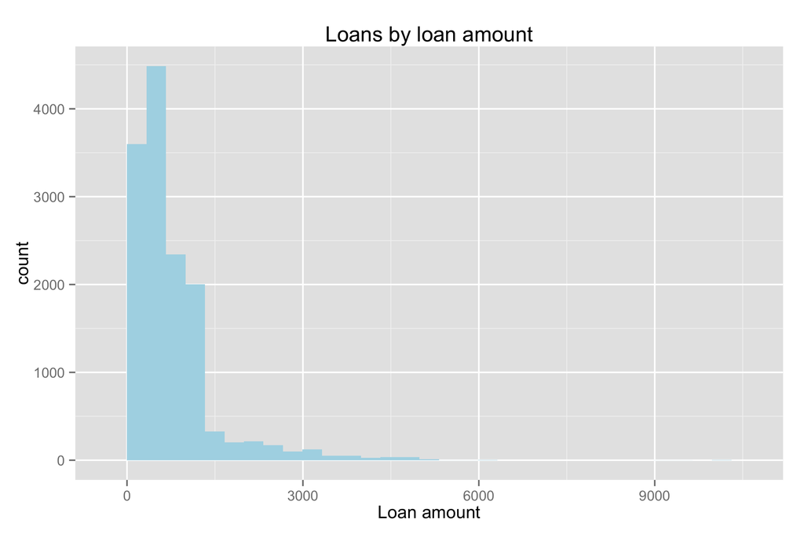

- 87% of loans went to single borrowers, while the other 13% went to multiple-borrower groups.

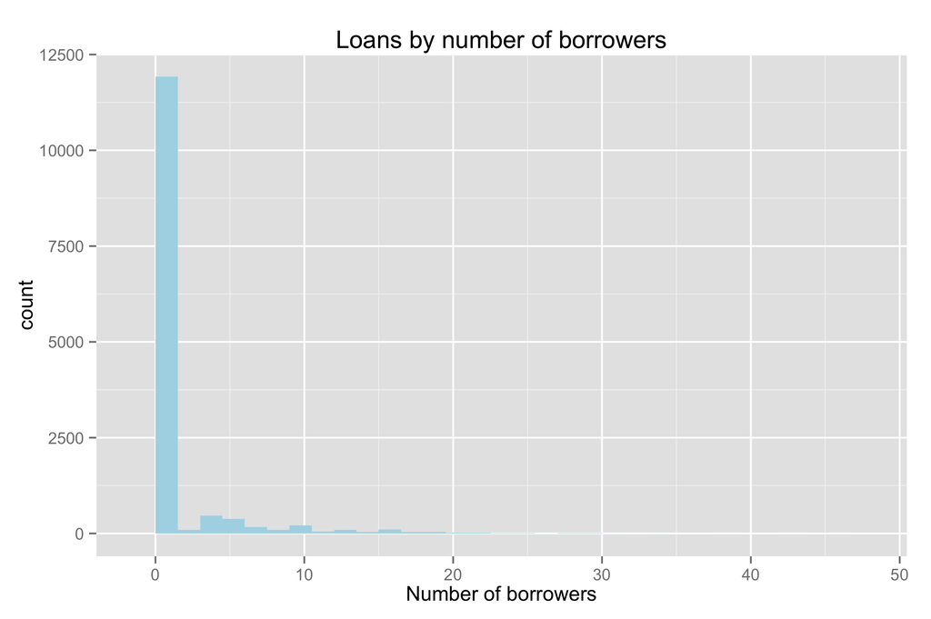

- 72% of loans went to females (or all-female groups).

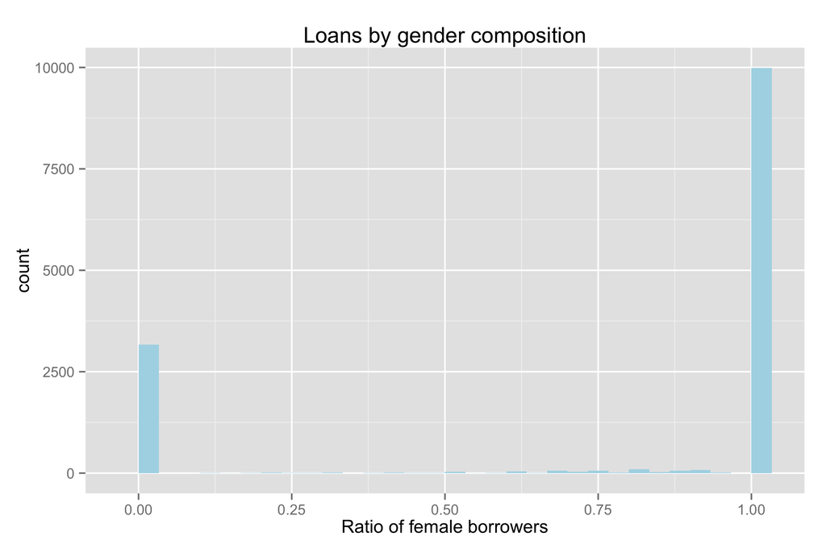

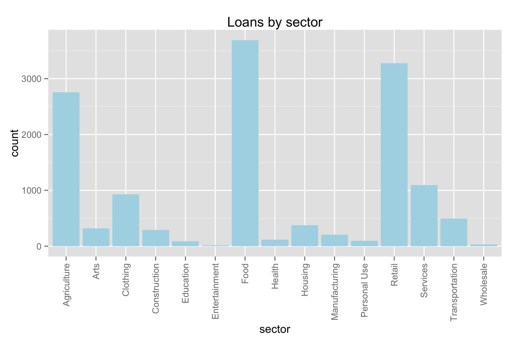

- The average loan got funded by lenders quickly. The median loan was funded 0.71 days after it was posted on the Kiva site, while the mean loan was funded 4 days after it was posted.

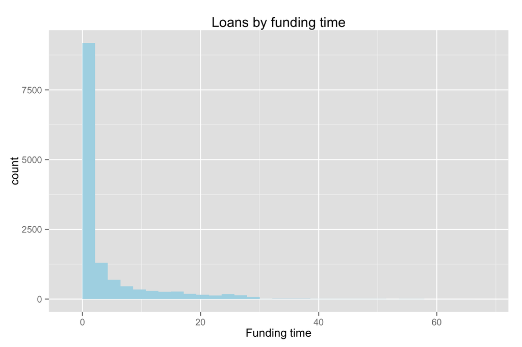

- The average loan was disbursed to borrowers about 15 days *before* it was posted. This practice of “pre-disbursing” loans is in keeping with Kiva’s practice of not waiting to help those who need helps, but it does throw a wrinkle into any supply chain analysis.
- The median loan was repaid by the borrower in 280 days, while the mean loan took 303 days to be reapid.

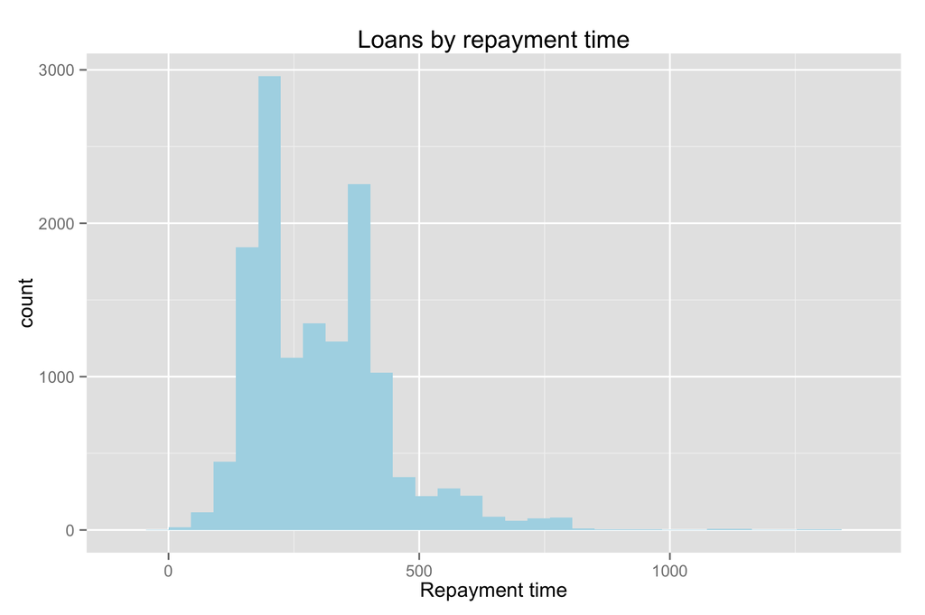

Upon initial inspection of the sample, we observed that:

- The amount of the loan was (linearly) correlated with the number of borrowers.
- The amount of the loan was correlated with the number of days it took for the loan to get funded and repaid.
- There was a clear relationship between the country and loan amount.
- There was no correlation between the loan amount and the length of the description.
- There was only a weak relationship between the gender make-up of the borrowing group and the loan amount.
- There was no discernible relationship between sector and loan amount, although different countries take out loans from different sectors at different frequencies:

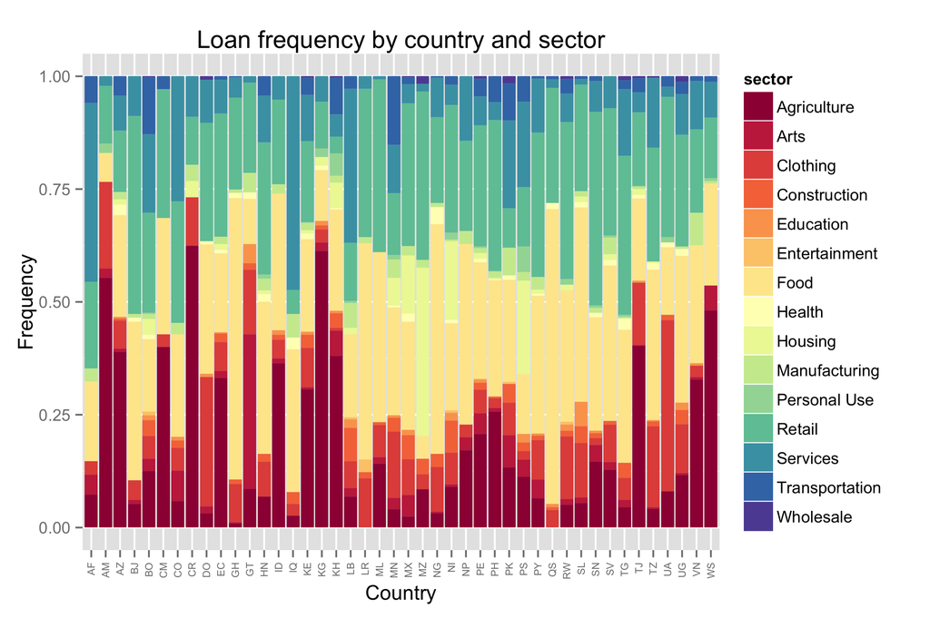

Interestingly, there was a statistically and practically significant difference in the funding times according to the gender composition of the group. Groups with female tended to get their loans funded 4.08 ± 0.37 days sooner than groups without females. Although this effect is partly explained by the loan amount – groups with females tend to take out smaller loans, which tend to take less time to fund – the effect does not disappear when we examine smaller loan amounts.

Given the somewhat unsurprising result that higher loan amounts are associated with longer funding and repayment times, we next considered funding and repayment **rates**. The median funding rate is 772 USD per day, and the median repayment rate is 1.92 USD per day. Unfortunately, most interesting lender behaviors *disappear* when we consider rates. That is, there are no differences in funding rate when we consider the borrower’s country or the borrower’s gender or the loan amount – although some sectors do tend to get funded more quickly (Education; Health) or others more slowly (Entertainment).

At the same time, there is a marked relationship between the *repayment rate* and the loan amount. Given its usefulness in forecasting available funds, the repayment rate suggested itself as a quantity worth trying to model and predict. In the scatterplot below, this rate is labeled `r.rate`:

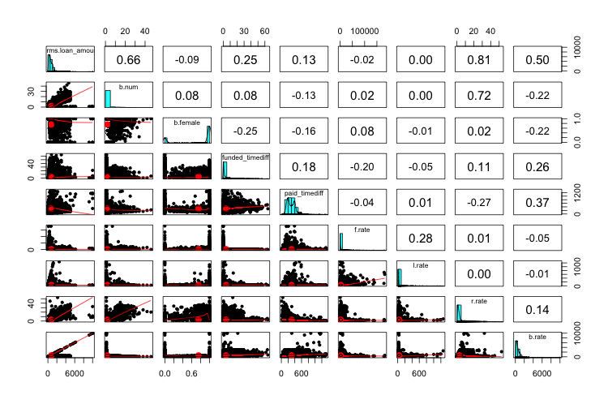

Investigating the scatterplots further, we found that there were two distinct classes of borrowers with different behaviors: single borrowers and multiple-borrower groups. When we considered the multiple-borrower class, we saw that the repayment rate was strongly correlated (r = 0.89) with the loan amount. Adding a male indicator variable – which is 1 when there is a male in the group – we found a weak correlation between a male presence and the loan amount, and thus with the repayment rate.

The borrower’s country also had a noticeable relationship with the repayment rate. When we looked at the multiple-borrower class, we saw a clear split by continent when the loan amount exceeded a certain threshold:

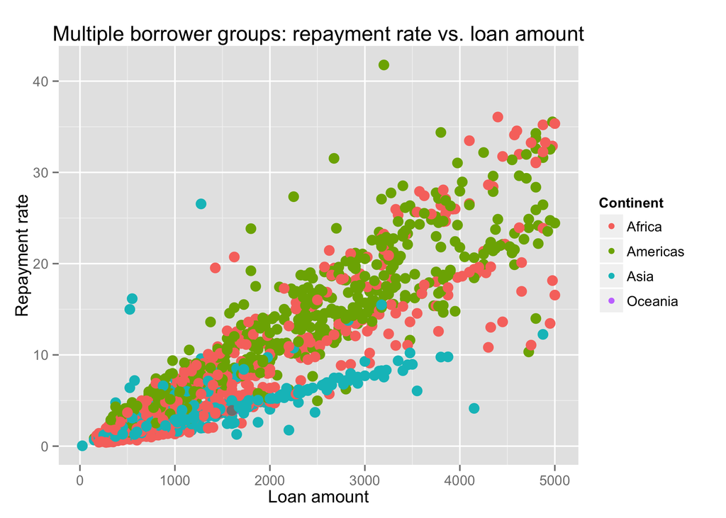

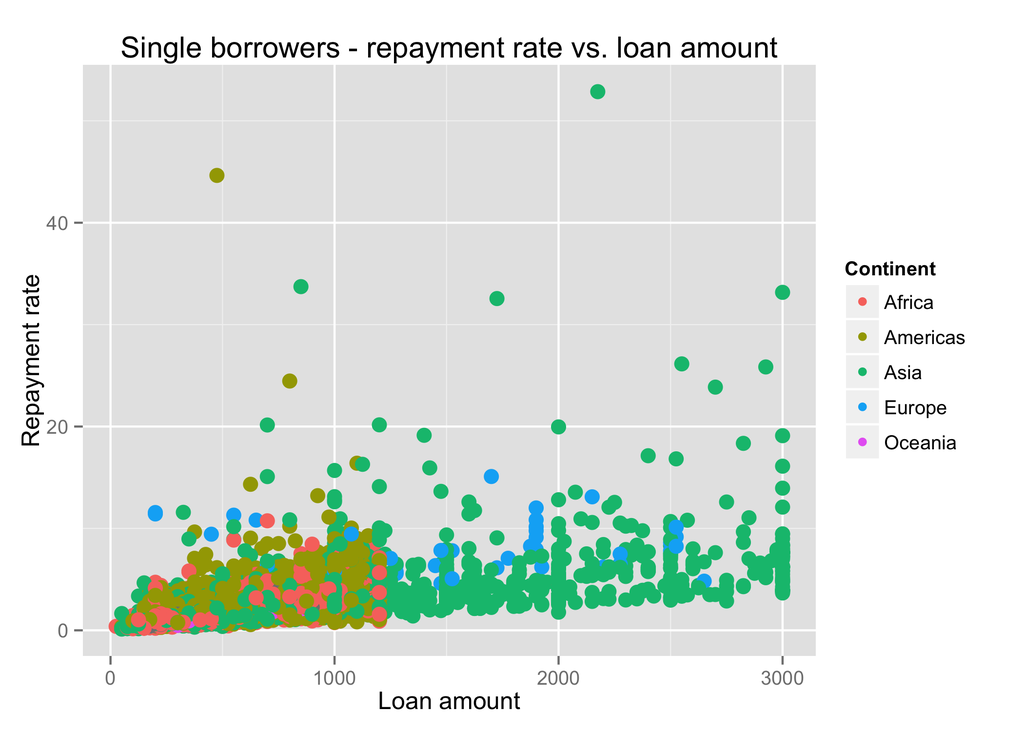

The starkness of this result may indicate a legal or tax-based restriction in these countries.

## Model of the repayment rate

Since correlations between lender behavior and variables of interested disappeared when we examined *rates* instead of quantities, we turned our attention to modeling the repayment rate, in the hope that it could help predict the pool of funds available to borrowers at a given time.

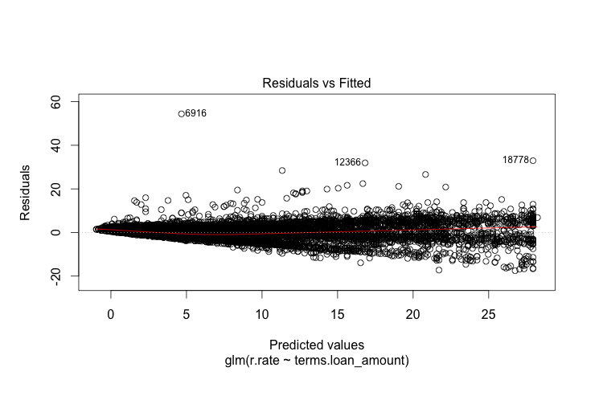

Nevertheless, we considered trying a model with more features. Optimizing for the Bayes Information Criterion (BIC), we selected a 22-feature model – most of these features being country indicator variables – and got the error down to 2.94 USD per day. The resulting model was reasonably interpretable but more complex and no less assumption-breaking.

To deal with the non-multivariate nature of our distributions and non-linear relationships in our data, we next tried a decision tree. The tree that we fit used both loan amount and continent as features, and returned an error of 3.64 USD per day – perhaps continent was a less useful feature than country.

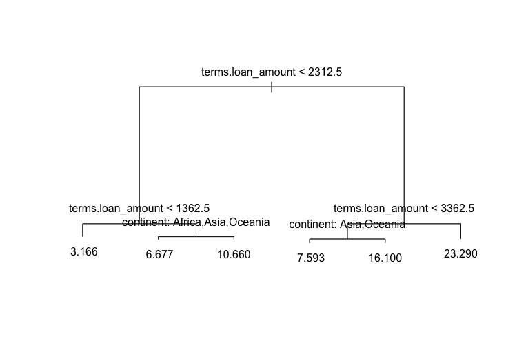

Finally, we moved to a random forest model, where we did better, bringing the error down to 2.55 USD per day. The forest picked out loan amount and country as the most important variables, as expected, and it seemed better at handling the inherent non-linearity in the data. Two different variable importance measures are shown below:

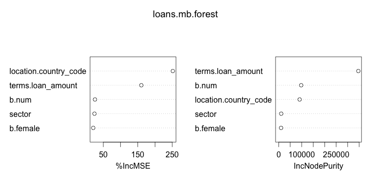

Even the random forest, however, had trouble with very high repayment rates. In other words, it struggled to account for borrowers who paid their loans back very quickly. We removed the upper decile of repayment rate from the data set, and our error fell to 1.51 USD per day. So, we have a model that does reasonably well at predicting the repayment rate for normal borrowers, but we need to figure out how to deal with borrowers who repay quickly – and of course, we still ned to treat the single-borrower class.